# R_PROJECT

GGPLOT

2024-04-18

**GGPLOT Questions**

**USE mtcars default data**

1.Histogram of hwy mpg values.

```r
library(ggplot2)
```

```r
data(mtcars)
head(mtcars)
```

```
##                    mpg cyl disp  hp drat    wt  qsec vs am gear carb
## Mazda RX4         21.0   6  160 110 3.90 2.620 16.46  0  1    4    4
## Mazda RX4 Wag     21.0   6  160 110 3.90 2.875 17.02  0  1    4    4
## Datsun 710        22.8   4  108  93 3.85 2.320 18.61  1  1    4    1
## Hornet 4 Drive    21.4   6  258 110 3.08 3.215 19.44  1  0    3    1
## Hornet Sportabout 18.7   8  360 175 3.15 3.440 17.02  0  0    3    2
## Valiant           18.1   6  225 105 2.76 3.460 20.22  1  0    3    1
```

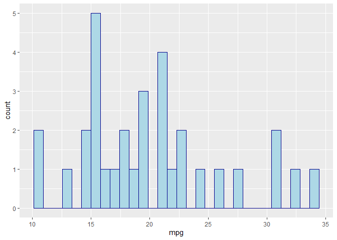

```r
ggplot(mtcars,aes (x = mpg) ) + geom_histogram(color="darkblue",
            fill="lightblue")
```

2.Barplot of car counts per manufacturer with color fill defined by cyl count.

```r
a = row.names(mtcars)
a
```

```
##  [1] "Mazda RX4"           "Mazda RX4 Wag"       "Datsun 710"
##  [4] "Hornet 4 Drive"      "Hornet Sportabout"   "Valiant"
##  [7] "Duster 360"          "Merc 240D"           "Merc 230"
## [10] "Merc 280"            "Merc 280C"           "Merc 450SE"
## [13] "Merc 450SL"          "Merc 450SLC"         "Cadillac Fleetwood"
## [16] "Lincoln Continental" "Chrysler Imperial"   "Fiat 128"
## [19] "Honda Civic"         "Toyota Corolla"      "Toyota Corona"
## [22] "Dodge Challenger"    "AMC Javelin"         "Camaro Z28"
## [25] "Pontiac Firebird"    "Fiat X1-9"           "Porsche 914-2"
## [28] "Lotus Europa"        "Ford Pantera L"      "Ferrari Dino"
## [31] "Maserati Bora"       "Volvo 142E"
```

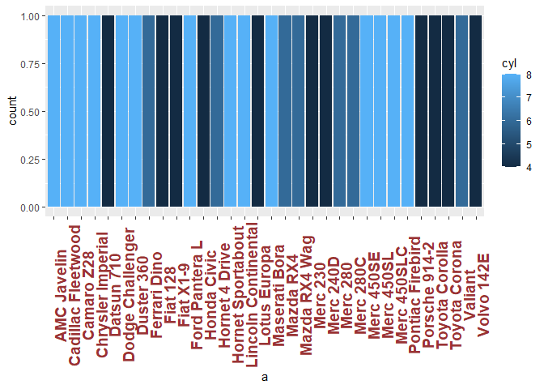

```r
ggplot(mtcars,aes(x=a,fill =cyl))+geom_bar()+ theme(axis.text.x = element_text(face="bold", color="#993333", size=14, angle=90))
```

3.Switch now to use the txhousing dataset that comes with ggplot2.

```r
data( txhousing )
 head(txhousing)
```

```
## # A tibble: 6 × 9
##   city     year month sales   volume median listings inventory  date
##   <chr>   <int> <int> <dbl>    <dbl>  <dbl>    <dbl>     <dbl> <dbl>
## 1 Abilene  2000     1    72  5380000  71400      701       6.3 2000
## 2 Abilene  2000     2    98  6505000  58700      746       6.6 2000.
## 3 Abilene  2000     3   130  9285000  58100      784       6.8 2000.
## 4 Abilene  2000     4    98  9730000  68600      785       6.9 2000.
## 5 Abilene  2000     5   141 10590000  67300      794       6.8 2000.
## 6 Abilene  2000     6   156 13910000  66900      780       6.6 2000.
```

4.Create a scatterplot of volume versus sales. Afterwards play around with alpha and color arguments to clarify information.

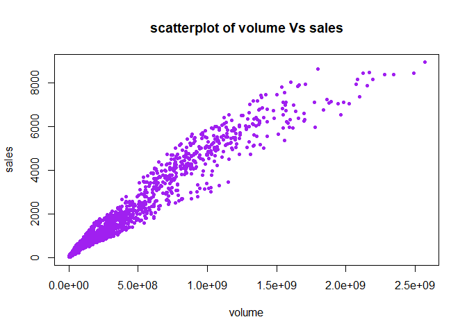

```r
x =txhousing$volume
y =txhousing$sales
plot(x,y, xlab ='volume',ylab ='sales',main ='scatterplot of volume Vs sales',col ='purple',pch =20 )+geom_point(alpha=0.6)
```

5.Add a smooth fit line to the scatterplot from above. Hint: You may need to look up geom_smooth().

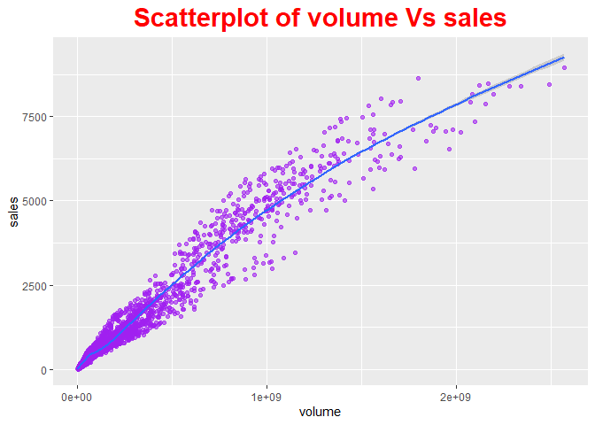

```r
ggplot(txhousing, aes(x =volume,y = sales,na.rm = TRUE))+geom_point(col =' purple',
alpha=0.6,na.rm = TRUE)+ggtitle("Scatterplot of volume Vs sales")+
  theme(plot.title = element_text(size =rel(2.0),face="bold",hjust =0.5,color ='red'))+geom_smooth(na.rm = TRUE)
```

**USE airquality default data**

4.Add a smooth trend line to the plot.

```r
data(airquality)
head(airquality)
```

```
##   Ozone Solar.R Wind Temp Month Day
## 1    41     190  7.4   67     5   1
## 2    36     118  8.0   72     5   2
## 3    12     149 12.6   74     5   3
## 4    18     313 11.5   62     5   4
## 5    NA      NA 14.3   56     5   5
## 6    28      NA 14.9   66     5   6
```

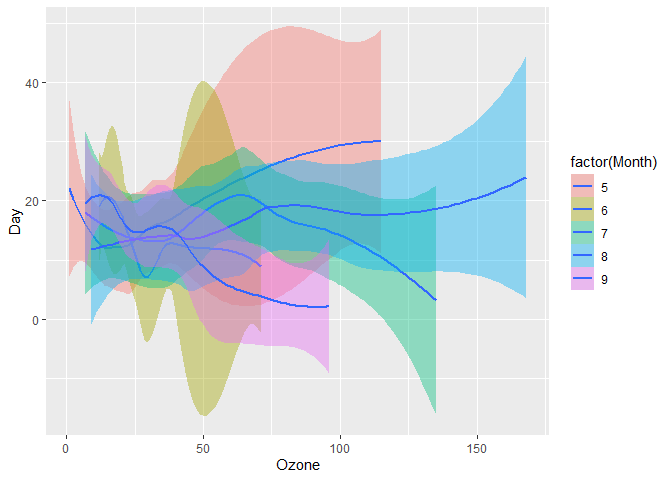

```r
ggplot(airquality, aes(x=Ozone, y=Day,fill =factor(Month),na.rm =TRUE))+geom_smooth(method = 'loess',na.rm =TRUE,formula = 'y ~ x')
```

**USE checkweight default data**

1.Plots Time on the x-axis and weight on the y-axis.

2.Uses different colors to represent each Diet.

3.Groups the lines by Chick to show individual growth trajectories within each diet.

```r
data(ChickWeight)
head(ChickWeight)
```

```
## Grouped Data: weight ~ Time | Chick
##   weight Time Chick Diet
## 1     42    0     1    1
## 2     51    2     1    1
## 3     59    4     1    1
## 4     64    6     1    1
## 5     76    8     1    1
## 6     93   10     1    1
```

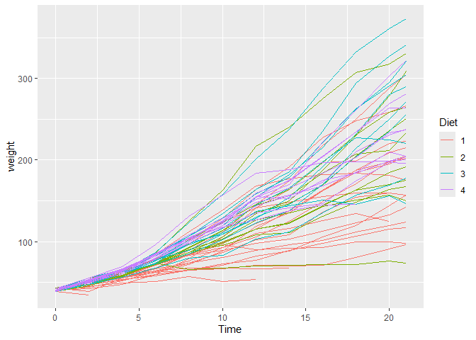

```r
ggplot(ChickWeight, aes(x =Time,y =weight,colour=Diet, group=Chick))+geom_line()
```

**USE diamonds default data**

Create a histogram to show the distribution of carat sizes. Then, refine your plot by:

1.Filling the bars based on the cut quality of the diamonds.

2.Limiting the x-axis to diamonds up to 3 carats for better detail.

```r
data(diamonds)
```

```r
head (diamonds)
```

```
## # A tibble: 6 × 10
##   carat cut       color clarity depth table price     x     y     z
##   <dbl> <ord>     <ord> <ord>   <dbl> <dbl> <int> <dbl> <dbl> <dbl>
## 1  0.23 Ideal     E     SI2      61.5    55   326  3.95  3.98  2.43
## 2  0.21 Premium   E     SI1      59.8    61   326  3.89  3.84  2.31
## 3  0.23 Good      E     VS1      56.9    65   327  4.05  4.07  2.31
## 4  0.29 Premium   I     VS2      62.4    58   334  4.2   4.23  2.63
## 5  0.31 Good      J     SI2      63.3    58   335  4.34  4.35  2.75
## 6  0.24 Very Good J     VVS2     62.8    57   336  3.94  3.96  2.48
```

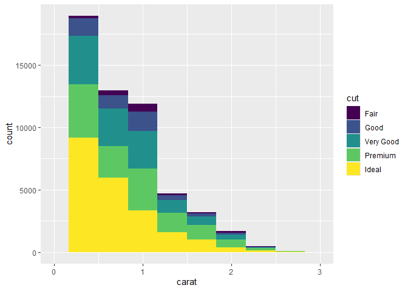

```r
ggplot(diamonds, aes(x =carat ,fill = cut,na.rm =TRUE))+geom_histogram(bins = 10,na.rm =TRUE)+ xlim(0, 3)
```